# Chapter 4. Basic Expressions and Function Writing

Sunday, October 12, 2014

**NOTICE**: The main references of this material are: * i) [learnR](http://renkun.me/learnR/): Chapter 3. Basic Expressions; * ii) [R Language Definition](http://cran.r-project.org/doc/manuals/R-lang.pdf): Chapter 3. Evaluation of Expressions, Chapter 4. Functions.

## Introduction

Expressions and functions play essential roles in R programming, especially when the analytic tasks are too complicated to use several existed functions to complete. In these situations, loops and functions are often used to control the execute procedure. In this chapter we will explore some basic but useful skills in R programming, and we will also have some examples related to finance study to show how to organize your idea, and how to transform mathematical models to R programs.

### Contents

- Basic Expressions
- Assignment
- Operators
- Conditions
- Loop
- Function Writing
- Elements of a Function
- Syntax
- Arguments
- Return
- Statements
- Advanced Topics
- apply() Family
- Get to Know apply() Family Functions
- Looping in apply()
- Anonymous Function in *apply()
- Applications
- Fibonacci Sequence
- Discrete Markov Chain
- Basic Option Pricing Models
- Split-Apply-Combine Strategy in Data Manipulation
- Karlman Filter

## Basic Expressions

### Assignment

Assignment might be the most fundamental expression in every programming language. An object in R can be imagined as a box, and we are able to put anything we want into the box by assignment.

We have several choices to perform this assignment. For example, if we want to create a sequence starts from 1 and ends at 5, and assign it to `x`:

```r
1:5       # it will be displayed in console but stored in nowhere
```

```
## [1] 1 2 3 4 5
```

```r
x <- 1:5  # first way to assign it
1:5 -> x  # second way
x = 1:5   # third way
```

We might be familiar with the third way but the most often used is the first one (using `<-`) in R.

Assignment chain is also allowed in R:

```r
x <- y <- z <- 0
c(x, y, z)
```

```
## [1] 0 0 0
```

Notice the expression `0` is evaluated only once here. To verify how it works, we can change `0` to a random number generator.

```r
x <- y <- z <- rnorm(1)
c(x, y, z)
```

```
## [1] -1.283002 -1.283002 -1.283002
```

### Operators

`+,-,*,/` are all operators in R language. There are a number of operators in R. You may refer to [R Language Definition](http://cran.r-project.org/doc/manuals/R-lang.pdf) Page 10 to find all of them. Here we divide these operators into three categories: arithmetic operators, logical operators and others. We will also use some examples to show how they are used in R.

#### Mathematical Operators

Mathematical operators are easy to understand:

```r
x <- 2
y <- 5
x + y
```

```
## [1] 7
```

```r
x - y
```

```
## [1] -3
```

```r
x * y
```

```
## [1] 10
```

```r
x / y
```

```
## [1] 0.4
```

```r
x ^ y
```

```
## [1] 32
```

```r
x : y
```

```
## [1] 2 3 4 5
```

```r
y %% x  # modulus 5%%2 = 1
```

```
## [1] 1
```

```r
y %/% x # interger divide 5%/%2 = 2
```

```
## [1] 2
```

Notice, `*` is different from what we have learned in math class when it is applied to matrices. To perform the so-called “matrix product”, we should use `%*%`.

```r
x <- matrix(1:9, nrow=3)
y <- matrix(1:9, nrow=3, byrow=TRUE)
x * y
```

```
##      [,1] [,2] [,3]
## [1,]    1    8   21
## [2,]    8   25   48
## [3,]   21   48   81
```

```r
x %*% y
```

```
##      [,1] [,2] [,3]
## [1,]   66   78   90
## [2,]   78   93  108
## [3,]   90  108  126
```

#### Logical Operators

Logical operators, or Boolean operators are used to calculate logical relationships. The first thing we should know is that logical value, which includes `TRUE` and `FALSE`, is also a kind of variable.

```r
x <- TRUE
class(x)
```

```
## [1] "logical"
```

The simplest situation happens when we want to know whether a statement is true or not.

```r
x <- 1
y <- 2
z <- 2
x > y
```

```
## [1] FALSE
```

```r
z >= y
```

```
## [1] TRUE
```

```r
z == y
```

```
## [1] TRUE
```

```r
x == y
```

```
## [1] FALSE
```

```r
z != y
```

```
## [1] FALSE
```

These operators are used to compare the values of two variables.

R also provides a useful operator `%in%` to find if a certain element exist in another object.

```r
y <- c(1, 3, 5, 6)
3 %in% y
```

```
## [1] TRUE
```

```r
4 %in% y
```

```
## [1] FALSE
```

See what happens if we do it this way:

```r
x <- c(1, 2, 4, 6)
y <- c(1, 3, 5, 6)
x %in% y
```

```
## [1]  TRUE FALSE FALSE  TRUE
```

Using these operators, we can find if a statement is true or not. However, sometimes we also need to calculate the relationship of two logical values. The basic calculations of two logical values are `and`, `or` and `not`. `and` and `or` combines two simple statement into one complex/compound statement, and `not` reverses the logical value.

```r
x <- TRUE
y <- FALSE
x | y
```

```
## [1] TRUE
```

```r
x & y
```

```
## [1] FALSE
```

```r
!(x) & y
```

```
## [1] FALSE
```

```r
!(x | y)
```

```
## [1] FALSE
```

Notice, two operators are provided to calculate `and`: `&` and `&&`. Also two operators for `or`: `|` and `||`. We must be clear about their differences.

```r
x <- c(TRUE, FALSE, TRUE)
y <- c(FALSE, TRUE, TRUE)
x & y
```

```
## [1] FALSE FALSE  TRUE
```

```r
x && y
```

```
## [1] FALSE
```

```r
x | y
```

```
## [1] TRUE TRUE TRUE
```

```r
x || y
```

```
## [1] TRUE
```

In R, `&` and `|` are called vectorized logical operators, and `&&` and `||` are non-vectorized logical operators. Remind this is different with C.

#### Other Operators

`$` and `~` are also listed as operators. `$` is used in select objects in a certain environment. `~` is often used in formulas. We will talk about it in future discussions.

### Conditions

How to tell my computer I want to execute certain codes only if some conditions are satisfied, and skip those lines when not satisfied?

```r
if( condition ){
  statement
}
```

In this code, R will evaluate the condition and test if it is satisfied or not. The statement in bracket will be executed only if `condition` equals TRUE.

```r
x <- 2
if( x == 1 ){
  test <- 1
}
test
```

Here we can find that `test` is not even existed! The example above also shows a often met mistake. Since we do not have to declare a variable before we use it, which is required in C/Cpp and many other languages, we must be careful about the logic of the program.

We may add `else` to test further conditions.

```r
if( condition.1 ){
  statement.1
} else if( condition.2 ) {
  statement.2
} else {
  statement.3
}
```

For example,

```r
signal <- 1

if( signal == 1 ){
  action <- "Open Long"
} else if( signal == -1 ){
  action <- "Open Short"
} else if( signal == 0 ){
  action <- "Close Position"
} else {
  action <- "Continue"
}

action
```

```
## [1] "Open Long"
```

For convenience, if-else sentence can be written in a single line.

```r
if( condition ) statement.1 else statement.2
```

Function `ifelse()` is very useful when the statement line is short:

```r
x <- 3
y <- ifelse(x == 2, x^2, x*3)
y
```

```
## [1] 9
```

Besides the logical operators we have mentioned, function `any()` and `all()` are also often used when there are a lot of conditions to test.

```r
x <- c(1, 3, 5, 2)
x > 2
```

```
## [1] FALSE  TRUE  TRUE FALSE
```

```r
x == 3
```

```
## [1] FALSE  TRUE FALSE FALSE
```

```r
all( x > 2 )
```

```
## [1] FALSE
```

```r
any( x == 3)
```

```
## [1] TRUE
```

`switch()` is also used to deals with conditions, but in a different way.

```r
switch(1,"x","y") # the n-th argument will be returned.
```

```
## [1] "x"
```

```r
switch(2,"x","y")
```

```
## [1] "y"
```

If the number is larger than the number of followed arguments, a `NULL` will be returned.

```r
switch(3,"x","y")
```

`switch()` performs differently when the input is a character.

```r
switch("a",a=1,b=2)
```

```
## [1] 1
```

```r
switch("b",a=1,b=2)
```

```
## [1] 2
```

```r
switch("c",a=1,b=2)
```

Note that `switch()` might be helpful to write a user-friendly function, since various situations might happen and we must test what the user really want to do.

### Loop

Computers does not know how to prove a new mathematical theorem, but knows how to finish simple calculations thousands times within seconds.

By looping, we divide a complicated task into repeated calculations. For example, using `for-looping`:

```r
y <- 0
for( i in 1:100 ){
  y <- y+i
}

y
```

```
## [1] 5050
```

From this example you may guess how `for-loop` works in R. General syntax for `for-loop` is

```r
for( iterator in vector ){
  statement to be evaluated each time
}
```

Notice 1, iterator is changing during the looping, and will still exist after loop (a kind of side effect).

Notice 2, we usually use vectors for looping, but `list`, `data.frame` can also be used for looping.

```r
df <- data.frame(a=rnorm(100, mean=1), b=rnorm(100, mean=0), c=rnorm(100, mean=3) )
for( var in df ){
  message( mean(var) )
}
```

```
## 1.01168136022301
## 0.107780074526767
## 2.95525116886131
```

```r
lists <- list(a=rnorm(100, mean=1), b=rnorm(50, mean=0), c=rnorm(800, mean=3))
for( x in lists ){
  message( mean(x) )
}
```

```
## 1.06470952766083
## -0.0767156077383146
## 2.99268449798508
```

`next` and `break` gives us further controls over the program. `next` skips following lines, and `break` stops the current level loop.

```r
s <- 0
for( i in 1:10 ){
  if( i == 3 ) next
  if( i == 6 ) break
  s <- s+i
}

s
```

```
## [1] 12
```

Notice the positions of `next` and `break` lines will change the result.

```r
s <- 0
for( i in 1:10 ){
  if( i == 6 ) break
  s <- s+i
  if( i == 3 ) next
}

s
```

```
## [1] 15
```

`repeat` and `while` are also used for looping.

```r
repeat statement
```

Remember you must give termination condition and use `break` to stop the loop, and also the termination condition must be satisfied in future time, or you will never get out the loop! Actually sometimes it not easy to know whether the terminal condition will be satisfied in the “future”, and for this reason `repeat-loop` is seldom used in practice.

The last way to loop is `while-loop`.

```r
while( condition ){
  statement
}
```

`while-loop` is very similar to `repeat-loop`, but gives the termination condition more explicitly. In `while-loop`, the statement will be evaluated only if `condition` equals `TRUE`.

For the same reason, we must be careful about if the terminal condition can be satisfied.

```r
s <- 0
i <- 1  # remember to creat iterator by yourself.
while( s < 1000 ){
  s <- s + i
  i <- i + 1  # remember to renew your interator.
}

s
```

```
## [1] 1035
```

However, we are still able to use `for-loop` to do the same thing.

```r
s <- 0
for( i in 1:1e8 ){
  if( s+i >= 100 ) break
  s <- s + i
}

s
```

```
## [1] 91
```

## Function Writing

### Elements of A Function

Before starting learning how to write a function in R, we firstly consider what a function really is.

In mathematics, a function is a kind of rule. When we put a number `x` into the function, it will be mapped to another number `y`. It seems like a black-box if we ignore how `x` is processed in it and just focus on its input and output.

In any kind of programming language, function works in the same way. Consider function `factorial()`:

```r
factorial(5)
```

```
## [1] 120
```

This calculates $n\times(n-1)\times(n-2)\dots\times1$. Here the input number is `5`, the output number is `120`. And how the input number `5` is processed is given by the equation.

So we can divide a function into three parts: * 1. The input (`5`) * 2. The output (`120`) * 3. How the input is processed into the output. ( $n\times(n-1)\times(n-2)\dots\times1$)

In R (and in any other programming language), we define them as: * 1. Arguments * 2. Return * 3. Statements

If we want to write a function, we must be clear about all these three things. Ask yourself what are given, what you want, and how to connect these two things.

### Syntax

Different language has different syntax for writing functions. In R, we create a function in this way:

```r
function.name <- function( argument.1, argument.2 ){
  statements...
  return(result)
}
```

Here we just give a simple example:

```r
myfun <- function(x, a, b){
  y <- a + b*x
  return(y)
}
```

Notice, a function is also a kind of object in R:

```r
class(myfun)
```

```
## [1] "function"
```

When the function is created, we can use it just as any existed functions in R.

```r
myfun(x=3, a=1, b=2)
```

```
## [1] 7
```

### Arguments

#### Argument Matching

All of the following are allowed in R:

```r
myfun(x=3, a=1, b=2)
```

```
## [1] 7
```

```r
myfun(a=1, b=2, x=3)
```

```
## [1] 7
```

```r
myfun(3, 1, 2)
```

```
## [1] 7
```

```r
myfun(x=3, 1, 2)
```

```
## [1] 7
```

The first two examples are called “exact matching”, since they give the exact names of all arguments.

Also, we can use “partial matching” sometimes. (See [R Language Definition](http://cran.r-project.org/doc/manuals/R-lang.pdf), Page 23, 4.3.2)

#### Default Value

We can set default values to the function:

```r
myfun <- function(x, a=1, b=2){
  y <- a + b*x
  return(y)
}
```

We have different choices to call the function `myfun()`:

```r
myfun(1)
```

```
## [1] 3
```

```r
myfun(x=1, a=2, b=3)
```

```
## [1] 5
```

```r
myfun(1, a=3)
```

```
## [1] 5
```

( This actually used a mechanism inside R called “lazy evaluation”. To know more, read: [Lazy Evaluation](http://renkun.me/learnR/inside-r/lazy-evaluation.html) )

### Return

#### Using `return()`

In the examples above, we used `return()` to tell R which object to be returned when we call the function. However, `return()` is not a must in a function. R will return the last shown object.

```r
myfun <- function(x, a, b){
  y <- a + b*x
}
```

```r
myfun(3, 1, 2)

z <- myfun(3, 1, 2)
z
```

```
## [1] 7
```

Notice, at this time the result will not be shown, but it can still be assigned to another object.

We can also simplify the function in this way:

```r
myfun <- function(x, a, b) y <- a + b*x

z <- myfun(3, 1, 2)
z
```

```
## [1] 7
```

However, we usually recommend to explicitly write `return()` when we are not very familiar with R, in order to make the codes more readable.

#### What if we do not care about the return?

In some situations, we do not care about what its return is. We use these functions to plot, to write data, to edit a data frame directly and so on. These actions are also allowed in R, and they do not need a specific return.

For example, we want a function to plot `n` random numbers:

```r
plot.rnorm <- function(n){
  rand <- rnorm(n)
  plot(rand)
}
```

When we call this function, it will plot directly.

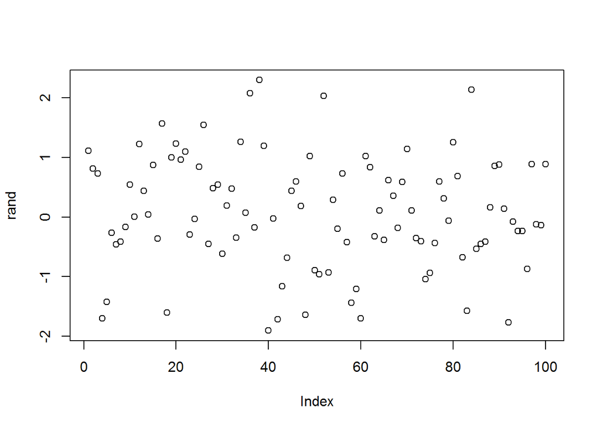

```r
plot.rnorm(100)
```

Still, we want to know what if we assign it to an object.

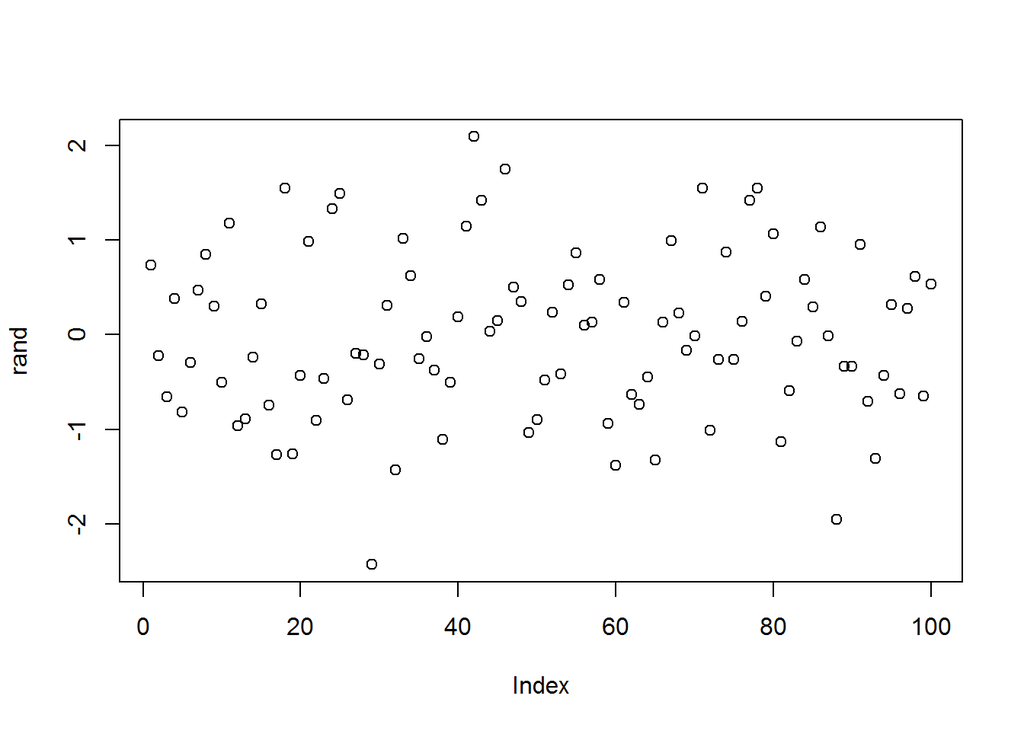

```r
test <- plot.rnorm(100)
```

```r
test
```

Think about why. The reason is `plot(rand)` is the last line in the function, and `plot()` function returns the `NULL`!

### Statements

There is no more thing to tell about statements, though these statements are the main body of a function. The reason is, you are writing in the same way as you are writing an R script.

### Further Topics

Here we just list some of the further topics of R programming, most of which will tell you the underlying mechanism of R. Though your codes still works if you have no idea about these stuffs, they will become important when you get more and more familiar with R.

- Recycling Rules (See [R Language Definition](http://cran.r-project.org/doc/manuals/R-lang.pdf), Page 15, 3.3.1)
- Copy on Write
- Lazy Evaluation ([learnR](http://renkun.me/learnR/inside-r/lazy-evaluation.html), 8.1)
- Scoping (See [R Language Definition](http://cran.r-project.org/doc/manuals/R-lang.pdf), Page 20, 3.5)
- Debugging (See [R Language Definition](http://cran.r-project.org/doc/manuals/R-lang.pdf), Page 40, 9)
- dot-dot-dot

## apply() Family

### Get to Know apply() Family Functions

#### `apply()`

`apply()` returns a vector or array or list of values obtained by applying a function to margins of an array or matrix. It is useful to deal with matrix and other high dimensional data. (From R base)

```r
x <- cbind(x1 = 3, x2 = c(4:1, 2:5))
dimnames(x)[[1]] <- letters[1:8]
apply(x, 2, mean, trim = .2)
```

```
## x1 x2
##  3  3
```

```r
col.sums <- apply(x, 2, sum)
row.sums <- apply(x, 1, sum)
```

#### `tapply()`

Apply a function to each cell of a ragged array, that is to each (non-empty) group of values given by a unique combination of the levels of certain factors.

```r
test <- data.frame(x=rnorm(1000, mean=2),
                   y=rpois(1000, lambda=3),
                   g=rep(LETTERS[1:5], 200))

tapply(test$x, test$g, mean)
```

```
##        A        B        C        D        E
## 2.064770 1.994454 2.009981 2.072133 2.024384
```

```r
tapply(test$y, test$g, mean)
```

```
##     A     B     C     D     E
## 3.075 2.945 3.125 2.965 2.910
```

#### `lapply()`

`lapply()` returns a list of the same length as X, each element of which is the result of applying FUN to the corresponding element of X.

```r
x <- list(a = 1:10,
          beta = exp(-3:3),
          logic = c(TRUE,FALSE,FALSE,TRUE))

lapply(x, mean)
```

```
## $a
## [1] 5.5
##
## $beta
## [1] 4.535125
##
## $logic
## [1] 0.5
```

```r
lapply(x, quantile)
```

```
## $a
##    0%   25%   50%   75%  100%
##  1.00  3.25  5.50  7.75 10.00
##
## $beta
##          0%         25%         50%         75%        100%
##  0.04978707  0.25160736  1.00000000  5.05366896 20.08553692
##
## $logic
##   0%  25%  50%  75% 100%
##  0.0  0.0  0.5  1.0  1.0
```

```r
lapply(x, quantile, probs = 1:4/5)
```

```
## $a
## 20% 40% 60% 80%
## 2.8 4.6 6.4 8.2
##
## $beta
##       20%       40%       60%       80%
## 0.1818441 0.6207277 2.0309691 6.4549012
##
## $logic
## 20% 40% 60% 80%
## 0.0 0.2 0.8 1.0
```

#### `sapply()`

```r
x <- list(a = 1:10,
          beta = exp(-3:3),
          logic = c(TRUE,FALSE,FALSE,TRUE))

sapply(x, mean)
```

```
##        a     beta    logic
## 5.500000 4.535125 0.500000
```

```r
sapply(x, quantile)
```

```
##          a        beta logic
## 0%    1.00  0.04978707   0.0
## 25%   3.25  0.25160736   0.0
## 50%   5.50  1.00000000   0.5
## 75%   7.75  5.05366896   1.0
## 100% 10.00 20.08553692   1.0
```

### Anonymous Function in `*apply()`

In some cases, R also allows anonymous functions. This is useful when you only want to use a function once.

```r
(function(x) 2*x)(2)
```

```
## [1] 4
```

Anonymous is very often used in `*apply()` family: We use `*apply()` to loop, and write anonymous functions in it.

```r
sapply(1:100, FUN = function(i){
  sim <- rnorm(100, mean=i)
  return(mean(sim))
})
```

```
##   [1]  1.211577  1.903013  2.973956  3.907141  4.971428  6.043779  6.955855
##   [8]  7.941472  9.075892  9.851919 11.165407 12.026522 12.913156 14.020909
##  [15] 14.831329 16.160448 16.948753 18.075150 19.027917 20.075084 21.081652
##  [22] 21.798050 22.800821 23.796987 25.047094 26.096160 27.116979 27.982983
##  [29] 29.053517 29.946254 31.029481 31.932604 32.998243 33.996204 34.988384
##  [36] 36.025766 36.889474 37.880496 39.030305 40.005103 41.162272 42.076876
##  [43] 42.935169 44.099604 44.733693 46.025441 46.940079 48.055164 48.825866
##  [50] 49.925047 51.031895 52.059636 53.073860 54.006466 54.952785 56.113463
##  [57] 56.981774 58.102183 59.072455 60.023927 61.079471 61.957986 63.100262
##  [64] 64.004200 64.900250 65.976728 66.882332 68.091118 68.851185 69.937204
##  [71] 70.929927 72.100455 73.125237 73.847770 75.008752 75.967995 77.024994
##  [78] 77.924087 78.858219 79.995742 80.903913 81.773258 82.893843 83.992518
##  [85] 84.957757 86.013971 87.273049 87.943863 89.027921 89.926606 90.898537
##  [92] 91.920024 93.076547 94.079995 94.999400 96.131348 97.076143 98.046132
##  [99] 99.223201 99.946668
```

```r
ul <- sapply(LETTERS, function(L){
  c(L, tolower(L))
})

t(ul)
```

```
##   [,1] [,2]
## A "A"  "a"
## B "B"  "b"
## C "C"  "c"
## D "D"  "d"
## E "E"  "e"
## F "F"  "f"
## G "G"  "g"
## H "H"  "h"
## I "I"  "i"
## J "J"  "j"
## K "K"  "k"
## L "L"  "l"
## M "M"  "m"
## N "N"  "n"
## O "O"  "o"
## P "P"  "p"
## Q "Q"  "q"
## R "R"  "r"
## S "S"  "s"
## T "T"  "t"
## U "U"  "u"
## V "V"  "v"
## W "W"  "w"
## X "X"  "x"
## Y "Y"  "y"
## Z "Z"  "z"
```

## Application

Equipped with the knowledge of operators, conditions and looping, we now come into a new topic: build your own program.

This is a very exiting part because it shows how you can tell your computer to work as you like and finish your tasks. Even the most complicated algorithm is generated from these structures, and you can show how creative you are using these basic tools.

### Fibonacci Sequence

The generation of Fibonacci sequence is often used as study examples and also used to test the efficiency of a programming language.

In Fibonacci sequence,

$F_{i}=F_{i-1}+F_{i-2}, i=3, 4, 5, \dots$

```r
n <- 50
fib <- c(1, 1)

for( i in 3:50 ){
  fib[i] <- fib[i-1] + fib[i-2]
}

fib
```

```
##  [1]           1           1           2           3           5
##  [6]           8          13          21          34          55
## [11]          89         144         233         377         610
## [16]         987        1597        2584        4181        6765
## [21]       10946       17711       28657       46368       75025
## [26]      121393      196418      317811      514229      832040
## [31]     1346269     2178309     3524578     5702887     9227465
## [36]    14930352    24157817    39088169    63245986   102334155
## [41]   165580141   267914296   433494437   701408733  1134903170
## [46]  1836311903  2971215073  4807526976  7778742049 12586269025
```

Now, consider to write a function to get a certain element of Fibonacci sequence.

Of course we can still use the method above and modify it as a function. The following codes shows that functions are allowed to call itself and thus able to complete recursive algorithm conveniently.

```r
fib <- function(n){
  if(n == 1 || n == 2){
    fib <- 1
  } else {
    fib <- fib(n-1) + fib(n-2)
  }
  return(fib)
}

fib(10)
```

```
## [1] 55
```

```r
sapply(1:20, fib)
```

```
##  [1]    1    1    2    3    5    8   13   21   34   55   89  144  233  377
## [15]  610  987 1597 2584 4181 6765
```

You may find that the calculation wastes a lot of resources. Advanced R[http://adv-r.had.co.nz/Function-operators.html] mentions a function called `memoise()` to memorise the outputs. A memoised function can run much faster because it stores all of the previous inputs and outputs, using more memory.

```r
system.time(fib(23))
system.time(fib(24))

library(memoise)
fib2 <- memoise(function(n) {
  if (n < 2) return(1)
  fib2(n - 2) + fib2(n - 1)
})
system.time(fib2(23))
system.time(fib2(24))
```

[output not shown]

Still, we want to show another way deal with this issue.

```r
fib_1 <- 1
fib_2 <- 1

sapply(1:50, function(i){
  fib <- fib_1 + fib_2
  fib_2 <<- fib_1
  fib_1 <<- fib

  return(fib)
})
```

```
##  [1]           2           3           5           8          13
##  [6]          21          34          55          89         144
## [11]         233         377         610         987        1597
## [16]        2584        4181        6765       10946       17711
## [21]       28657       46368       75025      121393      196418
## [26]      317811      514229      832040     1346269     2178309
## [31]     3524578     5702887     9227465    14930352    24157817
## [36]    39088169    63245986   102334155   165580141   267914296
## [41]   433494437   701408733  1134903170  1836311903  2971215073
## [46]  4807526976  7778742049 12586269025 20365011074 32951280099
```

`<<-` allows you to get out of the scope within a function.

### Discrete Markov Chain Simulation

Consider a discrete state transition stochastic process:

```r
trans.mat <- matrix(0, 3, 3)
trans.mat[1, ] <- c(0.1, 0.3, 0.6)
trans.mat[2, ] <- c(0.3, 0.4, 0.3)
trans.mat[3, ] <- c(0.4, 0.6, 0)
trans.mat
```

```
##      [,1] [,2] [,3]
## [1,]  0.1  0.3  0.6
## [2,]  0.3  0.4  0.3
## [3,]  0.4  0.6  0.0
```

How to simulate this process?

(Roulette Wheel Method in Probability Simulation)

```r
cum.trans.mat <- t( apply(trans.mat, MARGIN=1, cumsum) )
cum.trans.mat
```

```
##      [,1] [,2] [,3]
## [1,]  0.1  0.4    1
## [2,]  0.3  0.7    1
## [3,]  0.4  1.0    1
```

```r
state <- 2
sim <- c(state)

for( i in 2:1000 ){

  if( state == 1 ){
    rand <- runif(1)
    state <- ifelse(rand <= cum.trans.mat[1, 1], 1,
                    ifelse(rand <= cum.trans.mat[1, 2], 2, 3) )
    sim[i] <- state
  } else if ( state == 2 ){
    rand <- runif(1)
    state <- ifelse(rand <= cum.trans.mat[2, 1], 1,
                    ifelse(rand <= cum.trans.mat[2, 2], 2, 3) )
    sim[i] <- state
  } else if ( state == 3 ){
    rand <- runif(1)
    state <- ifelse(rand <= cum.trans.mat[3, 1], 1,
                    ifelse(rand <= cum.trans.mat[3, 2], 2, 3) )
    sim[i] <- state
  }

}
```

We can also simplify the codes. Think about why it works, and why `break` is needed in this code.

```r
for( i in 2:1000 ){
  for( j in 1:3 ){
    if( state == j ){
      rand <- runif(1)
      state <- ifelse(rand <= cum.trans.mat[j, 1], 1,
                      ifelse(rand <= cum.trans.mat[j, 2], 2, 3) )
      sim[i] <- state
      break
    }
  }
}
```

If there is no `break`, when `state == 1` is satisfied, the inner loop will be continued, `j` will be set to `2`, and the R will test `state == 2`. However, we have already changed variable `state` at this time.

Test if the simulation is consistency with the given matrix.

```r
test <- table( sim[1:999], sim[2:1000] )
test
```

```
##
##       1   2   3
##   1  24  79 168
##   2 118 163 140
##   3 129 178   0
```

```r
test/rowSums(test)
```

```
##
##              1          2          3
##   1 0.08856089 0.29151292 0.61992620
##   2 0.28028504 0.38717340 0.33254157
##   3 0.42019544 0.57980456 0.00000000
```

```r
trans.mat
```

```
##      [,1] [,2] [,3]
## [1,]  0.1  0.3  0.6
## [2,]  0.3  0.4  0.3
## [3,]  0.4  0.6  0.0
```

### Basic Option Pricing Models

#### Black-Scholes Option Pricing Model

Where $T$ is the a future time point, $t_0$ is right now. $S$ is the price of underlying asset, and $K$ is executive price of the option.

```r
S <- 50
K <- 52
r <- 0.01
sigma <- 0.5
Time <- 0.25
t0 <- 0

d1 <- ( log(S/K) + (r+sigma^2/2)*(Time-t0) ) / ( sigma*sqrt(Time-t0) )
d2 <- ( log(S/K) + (r-sigma^2/2)*(Time-t0) ) / ( sigma*sqrt(Time-t0) )

C <- S*pnorm(d1) - K*exp(-r*(Time-t0))*pnorm(d2)
P <- K*exp(-r*(Time-t0))*pnorm(-d2) - S*pnorm(-d1)

c(C, P)
```

```
## [1] 4.186028 6.056190
```

How to make the codes reusable? Notice both $C$ and $P$ are functions of parameters $S$, $T$, $t_0$, $\sigma$ and $r$.

$C=F_c(S, T, t_0, \sigma, r)$ $P=F_p(S, T, t_0, \sigma, r)$

Using them as arguments, we can write two functions to calculate the theoretical price.

```r
bs.eurocall <- function(S, K, r, sigma, Time, t0){
  d1 <- ( log(S/K) + (r+sigma^2/2)*(Time-t0) ) / ( sigma*sqrt(Time-t0) )
  d2 <- ( log(S/K) + (r-sigma^2/2)*(Time-t0) ) / ( sigma*sqrt(Time-t0) )

  eurocall <- S*pnorm(d1) - K*exp(-r*(Time-t0))*pnorm(d2)

  return(eurocall)
}

bs.eurocall(50, 52, 0.01, 0.5, 0.25, 0)
```

```
## [1] 4.186028
```

```r
bs.europut <- function(S, K, r, sigma, Time, t0){
  d1 <- ( log(S/K) + (r+sigma^2/2)*(Time-t0) ) / ( sigma*sqrt(Time-t0) )
  d2 <- ( log(S/K) + (r-sigma^2/2)*(Time-t0) ) / ( sigma*sqrt(Time-t0) )

  europut <- K*exp(-r*(Time-t0))*pnorm(-d2) - S*pnorm(-d1)

  return(europut)
}

bs.europut(50, 52, 0.01, 0.5, 0.25, 0)
```

```
## [1] 6.05619
```

Notice these these two functions are quite similar with each other. We can add an argument called “type” to control what kind of option is going to be calculated.

```r
bs.optprc <- function(type, S, K, r, sigma, Time, t0){
  d1 <- ( log(S/K) + (r+sigma^2/2)*(Time-t0) ) / ( sigma*sqrt(Time-t0) )
  d2 <- ( log(S/K) + (r-sigma^2/2)*(Time-t0) ) / ( sigma*sqrt(Time-t0) )

  if(type == "euro.call") optprc <- S*pnorm(d1) - K*exp(-r*(Time-t0))*pnorm(d2)
  if(type == "euro.put")  optprc <- K*exp(-r*(Time-t0))*pnorm(-d2) - S*pnorm(-d1)

  return(optprc)
}

bs.optprc(type="euro.call", 50, 52, 0.01, 0.5, 0.25, 0)
```

```
## [1] 4.186028
```

#### Binomial Tree Model

Binomial tree model is another famous option pricing model. This model assumes the price of the underlying asset will go up or go down in a certain rate during every single period of time. We can calculate the change rate of price, and the probability to go up.

The final price of the option is introduced firstly, and then we can trace back to the original price and get the theoretical price right now.

```r
binom.optprc <- function(type, S, K, r, sigma, Time, N){

  dt <- Time/N

  u <- exp(sigma*sqrt(dt))
  d <- 1/u
  p <- (exp(r*dt)-d)/(u-d)

  tree <- matrix(0, nrow=N+1, ncol=N+1)

  for( y in 0:N ){
    if( type=='call' )  tree[y+1, N+1] <- max(0, S*(u^y)*(d^(N-y))-K )
    if( type=='put'  )  tree[y+1, N+1] <- max(0, K - S*(u^y)*(d^(N-y)) )
  }

  for( x in seq(from=N, to=1, by=-1) ){
    for( y in seq(from=1, to=x, by=1) ){
      if( type=='call' ) tree[y, x] <- exp(-r*dt)*(p*tree[y+1, x+1] + (1-p)*tree[y, x+1])
      if( type=='put'  ) tree[y, x] <- exp(-r*dt)*(p*tree[y+1, x+1] + (1-p)*tree[y, x+1])
    }
  }

  optprc <- tree[1, 1]

  return(optprc)
}

binom.optprc(type='call', S=50, K=52, r=0.01, sigma=0.5, Time=0.25, N=30)
```

```
## [1] 4.225282
```

```r
binom.optprc(type='put', S=50, K=52, r=0.01, sigma=0.5, Time=0.25, N=30)
```

```
## [1] 6.095444
```

### Split-Apply-Combine Strategy in Data Manipulation

(This example comes from: Data Manipulation, Chapter 3.)

Split-apply-combine strategy is quite often used in data analysis.

- Split: Split the data into different groups
- Apply: Apply your function to finish your analysis within each group
- Combine: Combine the result of each group

We will use data set `iris` (which is an example data set already exists in R) as an example. We want to know the first four variables’ mean of each kind of species.

```r
head(iris)
```

```
##   Sepal.Length Sepal.Width Petal.Length Petal.Width Species
## 1          5.1         3.5          1.4         0.2  setosa
## 2          4.9         3.0          1.4         0.2  setosa
## 3          4.7         3.2          1.3         0.2  setosa
## 4          4.6         3.1          1.5         0.2  setosa
## 5          5.0         3.6          1.4         0.2  setosa
## 6          5.4         3.9          1.7         0.4  setosa
```

#### Without a loop

We can split the data into three different data sets and calculate the mean one by one, and then combine them together.

```r
## Split
iris.set <- iris[iris$Species == "setosa", -5]
iris.versi <- iris[iris$Species == "versicolor", -5]
iris.virg <- iris[iris$Species == "virginica", -5]

## Apply
mean.set <- colMeans(iris.set)
mean.versi <- colMeans(iris.versi)
mean.virg <- colMeans(iris.virg)

## Combine
mean.iris <- rbind(mean.set, mean.versi, mean.virg)
rownames(mean.iris) <- c("setosa", "versicolor", "virginica")

mean.iris
```

```
##            Sepal.Length Sepal.Width Petal.Length Petal.Width
## setosa            5.006       3.428        1.462       0.246
## versicolor        5.936       2.770        4.260       1.326
## virginica         6.588       2.974        5.552       2.026
```

#### With a loop

Fortunately, there are just three kinds of flowers in this dataset. What if there are 100 groups to calculate?

```r
mean.iris.loop <- NULL
for( species in unique(iris$Species) ){
  iris_sub <- iris[iris$Species==species]
  col_means <- colMeans(iris_sub[, -5])
  mean.iris.loop <- rbind(mean.iris.loop, col_means)  # this way is not recommended
}

rownames(mean.iris.loop) <- unique(iris$Species)

mean.iris.loop
```

#### More Convenient Method

Actually, there still exists more convenient ways. Here we recommend you to read the following materials and get familiar with package `plyr`:

- The Split-Apply-Combine Strategy for Data Analysis, Hadley Wickham, 2011.
- Data Manipulation, Jaynal Albedin, Chapter 3.

```r
library(plyr)
ddply(iris, .variables = "Species", .fun = function(df.sub){
  colMeans(df.sub[, -5])
})
```

```
##      Species Sepal.Length Sepal.Width Petal.Length Petal.Width
## 1     setosa        5.006       3.428        1.462       0.246
## 2 versicolor        5.936       2.770        4.260       1.326
## 3  virginica        6.588       2.974        5.552       2.026
```

### Karlman Filter

At the end of this lecture, we discussed how to implement the model of Karlman Filter. Here we just provide an example: https://github.com/MiltonDeng/Milton-Repo/tree/master/Courses/SSM